# Stat107 Final Project

How do harmful air pollutant concentrations vary across different months within a year?

Author

Crystal Kuong, Gracelynne Mohan, Sumeet Sammi, Zoe Shum

Published

December 11, 2024

# Introduction

Air quality is a vital aspect of environmental health, impacting ecosystems and human well-being. It is determined by the presence of various pollutants including, but not limited to nitrogen dioxide and carbon monoxide. Poor air quality is commonly linked to climate change and wildlife damage, as well as serious health issues, including respiratory diseases, cardiovascular problems, and reduced life expectancy. Understanding air quality trends can evoke initiatives centered on reducing the concentration of air pollutants, creating a cleaner environment and improving quality of life.

## The Question

*This study investigates: How do harmful air pollutant concentrations vary across different months of the year?*

This study examines monthly variations in key air pollutants to identify patterns influenced by seasonal changes, human activities, or environmental factors. The pollutants analyzed include:

The specific pollutants we will explore in this study include:

1. **Carbon Monoxide** ($CO$): A colorless, odorless gas from incomplete fossil fuel combustion, harmful to humans by impairing oxygen delivery.
2. **Non-Methane Hydrocarbon** ($NMHC$)**:** Organic compounds (excluding methane) that contribute to ground-level ozone and secondary pollutants through photochemical reactions.
3. **Nitrogen Dioxide** ($NO_2$)**:** A reddish-brown gas from fossil fuel combustion, linked to acid rain, smog, and respiratory issues.
4. **Nitrogen Oxide** ($NOx$)**:** Gases from fossil fuel combustion that contribute to acid rain, smog, and ozone formation.
5. **Nitrogen Oxide** ($NOx$)**:** Similar to $NO_2$, a gas that is produced by combustion of fossil fuels, contributes to acid rain, smog, and ground level ozone.
6. **Ozone** ($O_3$)**:** A secondary pollutant formed from precursor emissions like $NOx$ and volatile organic compounds.

## Packages

```r
library(readxl)
library(ggplot2)
library(lubridate)
library(tidyverse)
library(dplyr)
```

## The Dataset

The **UCI Air Quality Dataset**, sourced from the University of California, Irvine via Kaggle, tracks hourly pollutant, temperature, and humidity levels from March 2004 to April 2005 for a specific area.

```r
air <- read_excel("AirQualityUCI.xls")
head(air)
```

```
# A tibble: 6 × 15
  Date                Time                `CO(GT)` `PT08.S1(CO)` `NMHC(GT)`
  <dttm>              <dttm>                 <dbl>         <dbl>      <dbl>
1 2004-03-10 00:00:00 1899-12-31 18:00:00      2.6          1360        150
2 2004-03-10 00:00:00 1899-12-31 19:00:00      2            1292        112
3 2004-03-10 00:00:00 1899-12-31 20:00:00      2.2          1402         88
4 2004-03-10 00:00:00 1899-12-31 21:00:00      2.2          1376         80
5 2004-03-10 00:00:00 1899-12-31 22:00:00      1.6          1272         51
6 2004-03-10 00:00:00 1899-12-31 23:00:00      1.2          1197         38
# ℹ 10 more variables: `C6H6(GT)` <dbl>, `PT08.S2(NMHC)` <dbl>,
#   `NOx(GT)` <dbl>, `PT08.S3(NOx)` <dbl>, `NO2(GT)` <dbl>,
#   `PT08.S4(NO2)` <dbl>, `PT08.S5(O3)` <dbl>, T <dbl>, RH <dbl>, AH <dbl>
```

The original dataset contained **9,357 observations** and **15 variables**. Variable columns 3-12 were renamed for clarity.

```r
# Rename columns 3-12
air <- air %>%
  rename(
    CO = `CO(GT)`,
    S_CO = `PT08.S1(CO)`,
    NMHC = `NMHC(GT)`,
    S_NMHC = `PT08.S2(NMHC)`,
    C6H6 = `C6H6(GT)`,
    NOx = `NOx(GT)`,
    S_NOx = `PT08.S3(NOx)`,
    NO2 = `NO2(GT)`,
    S_NO2 = `PT08.S4(NO2)`,
    S_O3 = `PT08.S5(O3)`
  )
```

| Variable | Description |
| --- | --- |
| `Date` | The date of the measurement |
| `Time` | The time of the measurement. |
| `CO` | Concentration of carbon monoxide ($CO$) in the air (µg/m³). |
| `S_CO` | Sensor measurement for $CO$ concentration. |
| `NMHC` | Concentration of non-methane hydrocarbons ($NMHC$) (µg/m³). |
| `C6H6` | Concentration of benzene ($C_6H_6$) in the air (µg/m³). |
| `S_NMHC` | Sensor measurement for NMHC concentration. |
| `NOx` | Concentration of nitrogen oxide ($NOx$) in the air (µg/m³). |
| `S_NOx` | Sensor measurement for $NOx$ concentration. |
| `NO2` | Concentration of nitrogen dioxide ($NO_2$) in the air (µg/m³). |
| `S_NO2` | Sensor measurement for $NO_2$ concentration. |
| `S_O3` | Sensor measurement for ozone ($O_3$) concentration |
| `T` | Temperature (Celsius) |
| `RH` | Relative humidity (g/m³) |
| `AH` | Absolute humidity (g/m³) |

### Tidying The Dataset

```r
#Summarize dataset (excluding Date and Time columns)
summary(air[, -c(1, 2)])
```

```
       CO               S_CO           NMHC             C6H6
 Min.   :-200.00   Min.   :-200   Min.   :-200.0   Min.   :-200.000
 1st Qu.:   0.60   1st Qu.: 921   1st Qu.:-200.0   1st Qu.:   4.000
 Median :   1.50   Median :1053   Median :-200.0   Median :   7.900
 Mean   : -34.21   Mean   :1049   Mean   :-159.1   Mean   :   1.866
 3rd Qu.:   2.60   3rd Qu.:1221   3rd Qu.:-200.0   3rd Qu.:  13.600
 Max.   :  11.90   Max.   :2040   Max.   :1189.0   Max.   :  63.700
     S_NMHC            NOx             S_NOx           NO2
 Min.   :-200.0   Min.   :-200.0   Min.   :-200   Min.   :-200.00
 1st Qu.: 711.0   1st Qu.:  50.0   1st Qu.: 637   1st Qu.:  53.00
 Median : 895.0   Median : 141.0   Median : 794   Median :  96.00
 Mean   : 894.6   Mean   : 168.6   Mean   : 795   Mean   :  58.15
 3rd Qu.:1105.0   3rd Qu.: 284.0   3rd Qu.: 960   3rd Qu.: 133.00
 Max.   :2214.0   Max.   :1479.0   Max.   :2683   Max.   : 340.00
     S_NO2           S_O3              T                  RH
 Min.   :-200   Min.   :-200.0   Min.   :-200.000   Min.   :-200.00
 1st Qu.:1185   1st Qu.: 700.0   1st Qu.:  10.900   1st Qu.:  34.10
 Median :1446   Median : 942.0   Median :  17.200   Median :  48.60
 Mean   :1391   Mean   : 975.1   Mean   :   9.778   Mean   :  39.49
 3rd Qu.:1662   3rd Qu.:1255.0   3rd Qu.:  24.100   3rd Qu.:  61.90
 Max.   :2775   Max.   :2523.0   Max.   :  44.600   Max.   :  88.70
       AH
 Min.   :-200.0000
 1st Qu.:   0.6923
 Median :   0.9768
 Mean   :  -6.8376
 3rd Qu.:   1.2962
 Max.   :   2.2310
```

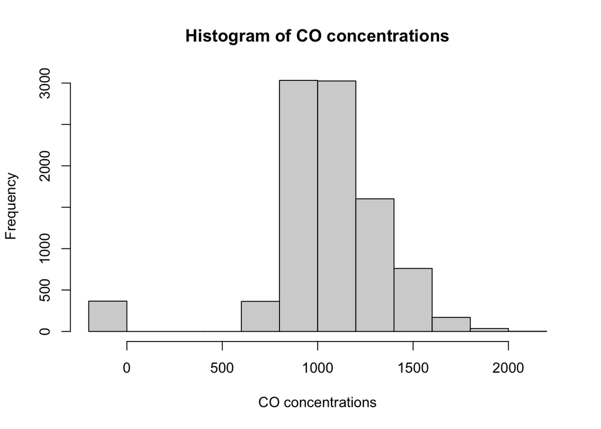

```r
# Histogram for S_CO
hist(air$S_CO,
     main = "Histogram of CO concentrations",
     xlab = "CO concentrations")
```

The summary statistics revealed an unusual minimum value of -200.00 was observed across all variables.

To investigate this anomaly, the variable S_CO was analyzed as a test case, revealing the value to be an outlier. To address these issues and enhance data quality, outliers were identified and removed using the **Interquartile Range (IQR) method**.

```r
# Calculate IQR
Q1 <- quantile(air$S_CO, 0.25, na.rm = TRUE)
Q3 <- quantile(air$S_CO, 0.75, na.rm = TRUE)
IQR <- Q3 - Q1

# Define outlier bounds
lower_bound <- Q1 - 1.5 * IQR
upper_bound <- Q3 + 1.5 * IQR

# Filter rows to remove outliers
air_filtered <- air[air$S_CO >= lower_bound & air$S_CO <= upper_bound, ]
```

The outcome:

- **484** total observations were removed.
- The distribution of `S_CO` shifted closer to normality, although still retaining a slight positive skew.

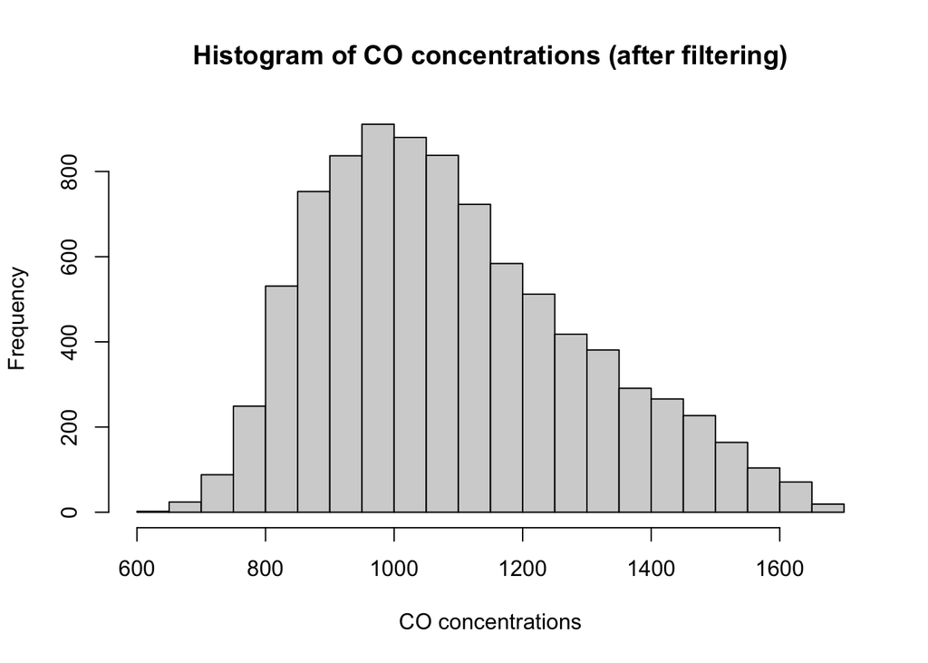

```r
hist(air_filtered$S_CO,
     main = "Histogram of CO concentrations (after filtering)",
     xlab = "CO concentrations")
```

### Reformatting The Dataset

To effectively analyze monthly variations in pollutant concentrations, the dataset will be reorganized by grouping the data by month and year, calculating the average values for each variable within these groups.

```r
# Reassign original dataset with filtered dataset
air <- air_filtered

# Convert 'Date' column to y-m-d format
air$Date <- ymd(air$Date)

# Create numerical Month and Year columns
air <- air %>%
  mutate(
    Month = month(Date, label = TRUE), # Extracts month as a numeric value (1-12)
    Year = year(Date)    # Extracts year
  )

# Group by Year and Month for summarization
airM <- air %>%
  group_by(Year, Month) %>%
  summarize(across(where(is.numeric),
                   ~mean(., na.rm = TRUE)),
            .groups = "drop")

head(airM, 5)
```

```
# A tibble: 5 × 15
   Year Month     CO  S_CO   NMHC  C6H6 S_NMHC   NOx S_NOx   NO2 S_NO2  S_O3
  <dbl> <ord>  <dbl> <dbl>  <dbl> <dbl>  <dbl> <dbl> <dbl> <dbl> <dbl> <dbl>
1  2004 Mar    -5.30 1197.   84.2  9.13   911. 119.  1045. 86.6  1541.  991.
2  2004 Apr   -64.4  1149.  102.   9.91   935.  19.4  945. -5.81 1593.  985.
3  2004 May   -36.5  1072. -199.  10.0    946.  62.2  951. 39.5  1595.  921.
4  2004 Jun   -20.3  1021. -200   10.6    966.  92.5  900. 65.0  1722.  938.
5  2004 Jul   -48.5  1046. -200   10.6    971. 113.   805. 90.5  1644.  994.
# ℹ 3 more variables: T <dbl>, RH <dbl>, AH <dbl>
```

Upon inspecting the dataset, several non-sensor measurements revealed unusual negative values, suggesting potential inaccuracies. For this reason, the analysis will prioritize sensor-based variables.

```r
# Disregard non-sensor pollutant measurements
airM <- airM[ ,-c(3,5,6,8,10)]

head(airM, 5)
```

```
# A tibble: 5 × 10
   Year Month  S_CO S_NMHC S_NOx S_NO2  S_O3     T    RH    AH
  <dbl> <ord> <dbl>  <dbl> <dbl> <dbl> <dbl> <dbl> <dbl> <dbl>
1  2004 Mar   1197.   911. 1045. 1541.  991.  14.3  50.2 0.785
2  2004 Apr   1149.   935.  945. 1593.  985.  16.8  50.7 0.919
3  2004 May   1072.   946.  951. 1595.  921.  20.3  43.5 0.957
4  2004 Jun   1021.   966.  900. 1722.  938.  26.5  39.9 1.28
5  2004 Jul   1046.   971.  805. 1644.  994.  29.4  33.1 1.24
```

# Analysis

## Graphs

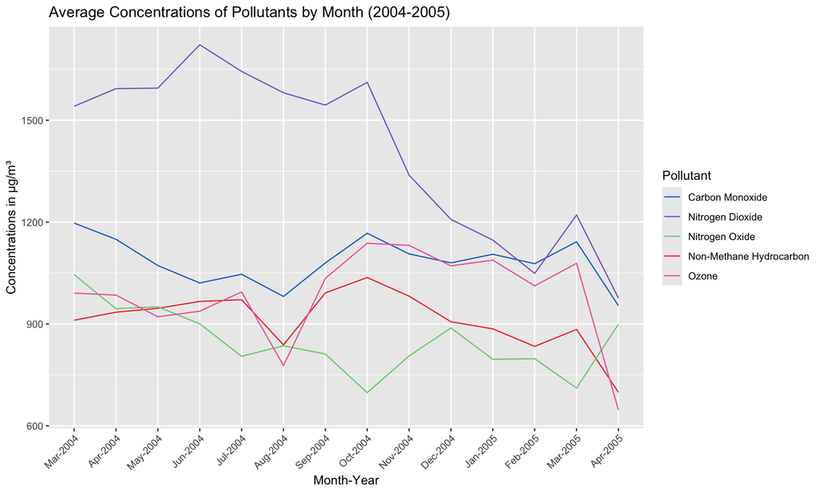

```r
# Plot monthly Concentrations
airM %>%
  # Use interaction to combine Month and Year
  ggplot(aes(x = interaction(Month, Year, sep = "-"))) +
  # Add points and lines for different pollutants
  geom_line(aes(y = S_CO, color = "Carbon Monoxide", group = 1)) +
  geom_line(aes(y = S_NMHC, color = "Non-Methane Hydrocarbon", group = 2)) +
  geom_line(aes(y = S_NOx, color = "Nitrogen Oxide", group = 3)) +
  geom_line(aes(y = S_NO2, color = "Nitrogen Dioxide", group = 3)) +
  geom_line(aes(y = S_O3, color = "Ozone", group = 3)) +
  labs(
    title = "Average Concentrations of Pollutants by Month (2004-2005)",
    x = "Month-Year",
    y = "Concentrations in µg/m³"
  ) +
  scale_color_manual(
    values = c("Carbon Monoxide" = "dodgerblue3",
               "Non-Methane Hydrocarbon" = "brown2",
               "Nitrogen Oxide" = "palegreen3",
               "Nitrogen Dioxide" = "mediumpurple3",
               "Ozone" = "hotpink2"),
    name = "Pollutant"
  ) +
  theme(axis.text.x = element_text(angle = 45, hjust = 1))  # Rotate x-axis labels
```

Nitrogen dioxide concentrations were notably higher than those of other pollutants from March to November 2004. While fluctuations were evident, certain trends stood out, such as a dip in August 2004 for ozone (pink), non-methane hydrocarbons (red), and carbon monoxide (blue). Additional dips occurred in February and April 2005, with the latter being more pronounced and severe. Interestingly, nitrogen oxide concentrations displayed a contrasting pattern compared to other pollutants. For example, in October 2004, when other pollutants peaked, nitrogen oxide concentrations reached their lowest levels.

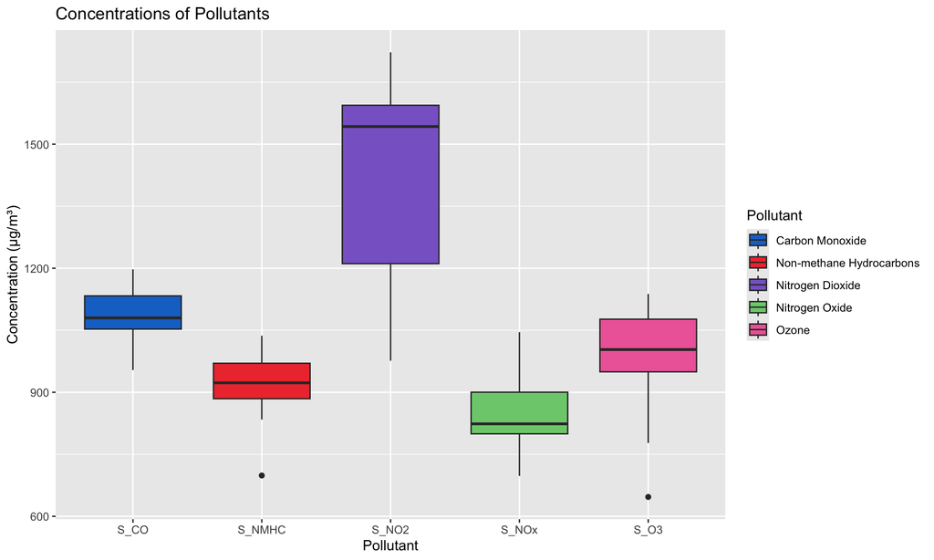

```r
# Pivot data frame by Pollutant
airM_2 <- airM %>%
  pivot_longer(
    cols = c(3:7),
    names_to = "Pollutant",
    values_to = "Concentration"
  )

# Plot Pollutant Concentrations
airM_2 %>%
  ggplot(aes(x = Pollutant)) +
  geom_boxplot(aes(y = Concentration, fill = Pollutant), size = 0.5) +
  labs(
    title = "Concentrations of Pollutants",
    x = "Pollutant",
    y = "Concentration (µg/m³)"
  ) +
  scale_fill_manual(
    values = c("dodgerblue3", "brown2", "mediumpurple3", "palegreen3", "hotpink2"), # Specify colors for each pollutant
    labels = c("Carbon Monoxide", "Non-methane Hydrocarbons", "Nitrogen Dioxide", "Nitrogen Oxide", "Ozone")
  )
```

The boxplot depicts the fluctuation of each pollutant. Most of the pollutants has a concentration lower than 1200 μg/ m3. On the other hand, nitrogen dioxide had the highest concentration at above 1500 μg/ m3. The high concentration of nitrogen dioxide is expected in urban areas where there is an abundance of fossil fuel combustion from cars.

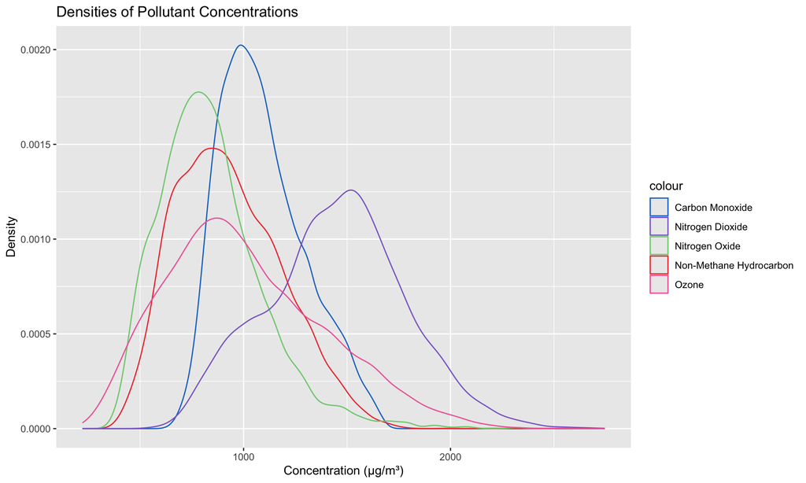

```r
ggplot() +
  geom_density(data = air, aes(x = S_CO, color="Carbon Monoxide")) +
  geom_density(data = air, aes(x = S_NMHC, color="Non-Methane Hydrocarbon")) +
  geom_density(data = air, aes(x = S_NOx, color="Nitrogen Oxide")) +
  geom_density(data = air, aes(x = S_NO2, color="Nitrogen Dioxide")) +
  geom_density(data = air, aes(x = S_O3, color="Ozone")) +
  labs(title = "Densities of Pollutant Concentrations", x = "Concentration (µg/m³)", y = "Density") +
  scale_color_manual(values = c("Carbon Monoxide" = "dodgerblue3", "Non-Methane Hydrocarbon" = "brown2", "Nitrogen Oxide" = "palegreen3","Nitrogen Dioxide" = "mediumpurple3","Ozone"  = "hotpink2"))
```

The Densities of Pollution Concentrations graph shows the distribution of pollution concentrations in µg/m³. Carbon Monoxide and Nitrogen Oxide have the highest peaks, indicating that there’s a lot of measurements recorded in those specific concentration ranges.

Some of the more spread out distributions, such as Ozone and Nitrogen Dioxide, show that there’s a wider variation in the levels of concentration. Non-methane Hydrocarbons and Nitrogen Oxide seem to have a correlation, which is likely because they tend to coexist in areas with high pollution.

## Regression Analysis

```r
# Generate some statistics
model1 <- lm(log(S_NOx) ~ (S_CO), data = air)
summary(model1)
```

```
Call:
lm(formula = log(S_NOx) ~ (S_CO), data = air)

Residuals:
     Min       1Q   Median       3Q      Max
-0.33932 -0.11111 -0.04294  0.07911  0.95268

Coefficients:
              Estimate Std. Error t value Pr(>|t|)
(Intercept)  7.984e+00  9.357e-03   853.3   <2e-16 ***
S_CO        -1.185e-03  8.432e-06  -140.6   <2e-16 ***
---
Signif. codes:  0 '***' 0.001 '**' 0.01 '*' 0.05 '.' 0.1 ' ' 1

Residual standard error: 0.1618 on 8871 degrees of freedom
Multiple R-squared:  0.6902,    Adjusted R-squared:  0.6901
F-statistic: 1.976e+04 on 1 and 8871 DF,  p-value: < 2.2e-16
```

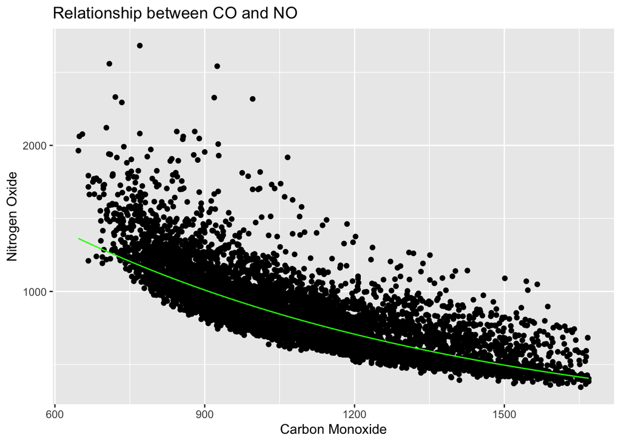

```r
air %>%
  ggplot() +
  geom_point(aes(x = S_CO, y = S_NOx)) +
  geom_line(
    aes(x = S_CO, y = exp(predict(model1, newdata = air))),
    color = "green"
  ) +
  labs(
    title = "Relationship between CO and NO",
    x = "Carbon Monoxide",
    y = "Nitrogen Oxide"
  )
```

In an attempt to track the inverse relationship that was previously observed in the line graph between carbon monoxide and nitrogen oxide, a regression analysis was conducted. After plotting the data points, there seemed to be an exponential relationship between the two variables and a regression analysis produced a r squared value of 0.69.

Therefore, there seems to be a moderate correlation between the variables. When carbon monoxide concentration levels go up, nitrogen oxide levels may be predicted to decrease at a decreasing rate, following a slow exponential decay.

# Conclusion

In conclusion, this study provided valuable insights into the variations in pollutant concentrations across different months and the seasonal trends influencing air quality. Notably, nitrogen dioxide levels were consistently high, likely due to the combustion of fossil fuels, while pollutants like ozone and carbon monoxide exhibited seasonal dips. Furthermore, the overall variation in pollutant levels across the year highlighted the dynamic nature of air quality, making identifying clear and consistent seasonal trends a challenge with the data currently available.

## Addressing Potential Errors

**Negative Values in the Dataset:** Negative values, such as “-200.00,” were assigned for missing or invalid data, leading to unrealistic negative means. To address this, we analyzed sensor measurements rather than actual pollutant concentrations.

**Outliers in the Dataset:** Outliers were identified using the IQR method, but this approach can exclude valid extreme values, highlighting the need for careful consideration when filtering data.

**Sensor Measurement Error:** Sensor errors due to calibration issues, environmental impacts, or sensor aging may result in inaccuracies, particularly in long-term data collection.

**Regional Specificity:** This dataset focuses on the pollutant concentrations in a specific area, meaning that the variation of air quality across different locations may not be represented well. Factors such as traffic, industry, and geographical features can influence the pollutant levels in the area. While the data provides valuable insights into the air quality of the area over time, the data generalizations are limited as a result of the limited sampling region.